# TBS for treating depression in elderly: Psychological measures

Matthias Lüthi

2025-07-22

The 2 measuers of interest for this analysis are the Autobiographical Memory Test (AMT) and the and the Revised NEO Personality Inventory (NEO PI-R).

# 1 Data cleaning

For all analyses, subjects were excluded that had:

- no NEO-PI and no AMT data.
- no NEO-PI and only baseline AMT data.

The remaining number of subjects is 79, which was used for descriptive statistics. There were 78 subjects with at least 2 AMT measures and 76 subjects had NEO-PI-R data.

# 2 Descriptives

## 2.1 Table 1

[output not shown]

*Notes:* N is provided where it deviates from the regular sample N. There were no cases of hyperthyroidism.

## 2.2 NEO PI-R

NEO PI-R was collected at week 6. It was not included in Table 1, which commonly only includes baseline data.

| Characteristic | Active TBS N = 40 | Sham TBS N = 36 | P |
| --- | --- | --- | --- |
| Neuroticismo | 107.1 ± 14.7 | 106.7 ± 12.5 | 0.911 |
| Extroversao | 95.7 ± 15.8 | 93.5 ± 12.2 | 0.493 |
| Abertura | 107.2 ± 16.6 | 97.8 ± 14.6 | 0.012 |
| Amabilidade | 120.7 ± 12.5 | 116 ± 10.4 | 0.079 |
| Conscienciosidade | 111.3 ± 15.3 | 109.1 ± 13.1 | 0.503 |
| Neuroticismo ansiedade | 18.6 ± 3.4 | 18.5 ± 2.7 | 0.834 |
| Neuroticismo raiva | 16.9 ± 3.6 | 17.9 ± 3.4 | 0.212 |
| Neuroticismo depressao | 19.6 ± 4.2 | 19.4 ± 3.1 | 0.762 |
| Neuroticismo embaraco | 19 ± 3.6 | 17.5 ± 3.2 | 0.062 |
| Neuroticismo impulsividade | 16.3 ± 4.4 | 16.2 ± 3 | 0.952 |
| Neuroticismo vulnerabilidade | 16.4 ± 3.7 | 17.2 ± 3.7 | 0.336 |
| Extroversao acolhimento | 20.1 ± 4.5 | 19 ± 3.8 | 0.270 |
| Extroversao gregarismo | 13.9 ± 4.7 | 14.7 ± 3.6 | 0.461 |
| Extroversao assertividade | 14.1 ± 3.7 | 14.1 ± 3.4 | 0.986 |
| Extroversao atividade | 14.6 ± 3.5 | 15.1 ± 3 | 0.497 |
| Extroversao busca de sensacoes | 16.5 ± 3.3 | 15.9 ± 2.7 | 0.423 |
| Extroversao emocoes positivas | 16.5 ± 4.8 | 14.7 ± 4 | 0.075 |
| Extroversao emocoes positivas extroversao | 40 ± 10.5 | 36.2 ± 8.9 | 0.097 |
| Abertura fantasia | 17.4 ± 4.3 | 15.1 ± 3.9 | 0.018 |
| Abertura estetica | 19.6 ± 4 | 17.6 ± 3.4 | 0.021 |
| Abertura sentimento | 18.4 ± 3.2 | 17.2 ± 3.1 | 0.092 |
| Abertura acoes variadas | 14.7 ± 3.7 | 14.6 ± 3.3 | 0.965 |
| Abertura ideias | 17.9 ± 4.4 | 16.2 ± 4.9 | 0.126 |
| Abertura valores | 19.3 ± 3.5 | 17.1 ± 3.5 | 0.008 |
| Amabilidade confianca | 17.9 ± 4.7 | 17.9 ± 3 | 0.966 |
| Amabilidade franqueza | 20.5 ± 3 | 20.2 ± 3.2 | 0.670 |
| Amabilidade altruismo | 21.9 ± 3.3 | 20.6 ± 3.4 | 0.100 |
| Amabilidade complacencia | 18.7 ± 3.4 | 16.8 ± 3 | 0.012 |
| Amabilidade modestia | 20.2 ± 2.5 | 19.6 ± 3 | 0.374 |
| Amabilidade sensibiliidade | 21.6 ± 2.8 | 20.9 ± 3.3 | 0.376 |
| Conscienciosidade competencia | 19.6 ± 3.2 | 18.8 ± 3.2 | 0.248 |
| Conscienciosidade ordem | 17.8 ± 4.3 | 16.9 ± 3 | 0.276 |
| Conscienciosidade senso de dever | 22.7 ± 3 | 22.6 ± 3.1 | 0.896 |
| Conscienciosidade esforco por realizacoes | 17.9 ± 3.6 | 17.6 ± 3.9 | 0.760 |
| Conscienciosidade autodisciplina | 15.3 ± 4.3 | 16.2 ± 2.9 | 0.310 |
| Conscienciosidade ponderacao | 18 ± 4.3 | 16.6 ± 4.6 | 0.160 |

*Notes:* Some significant findings were expected because of the amount of tests. Most notable is probably the difference in openness (abertura), which differed between groups even on the level of the combined scale.

# 3 Figures

All error bars represent 95% confidence intervals.

## 3.1 Longitudinal plots (HDRS & AMT)

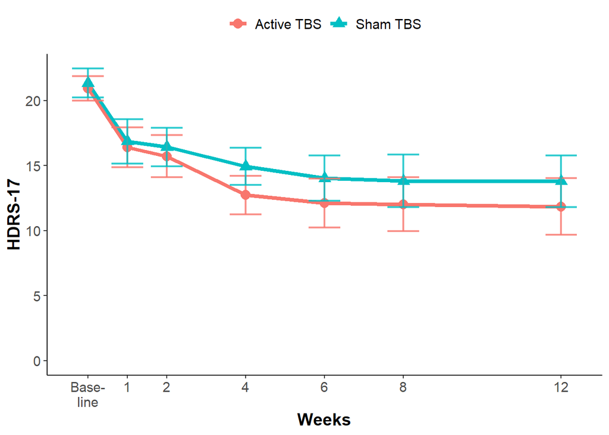

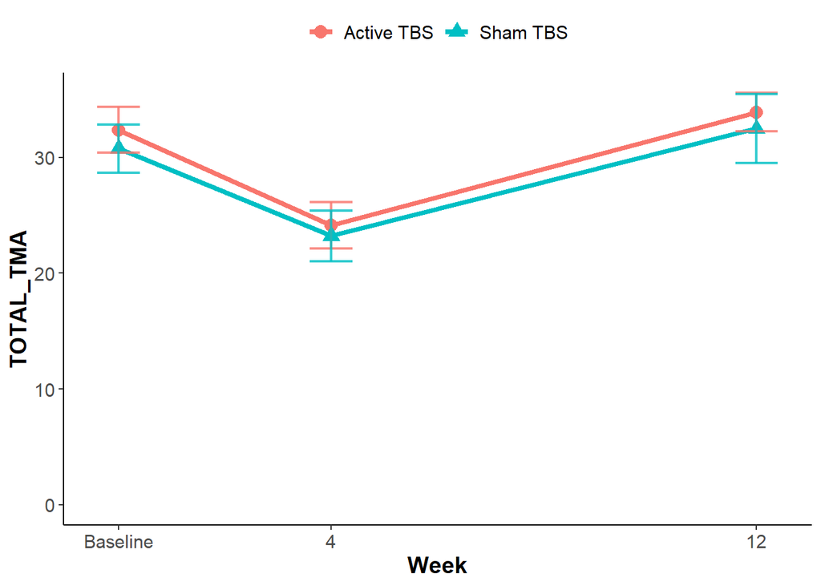

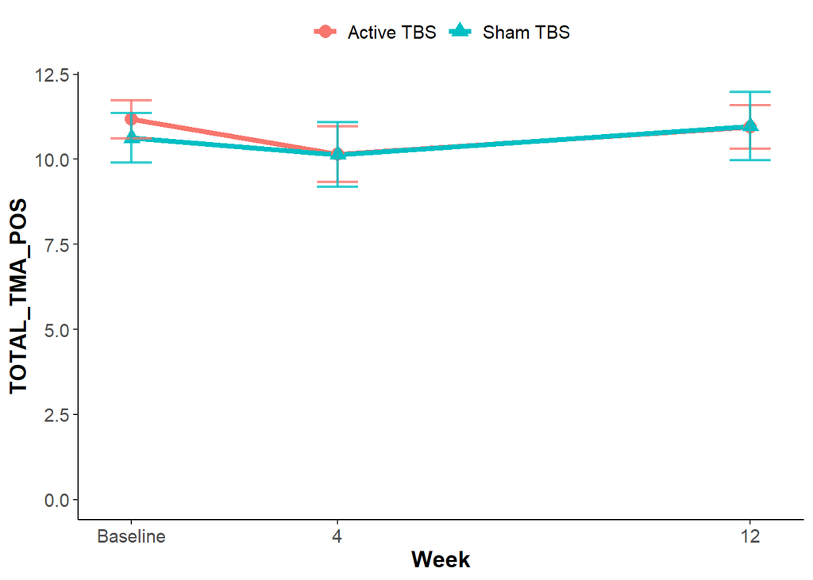

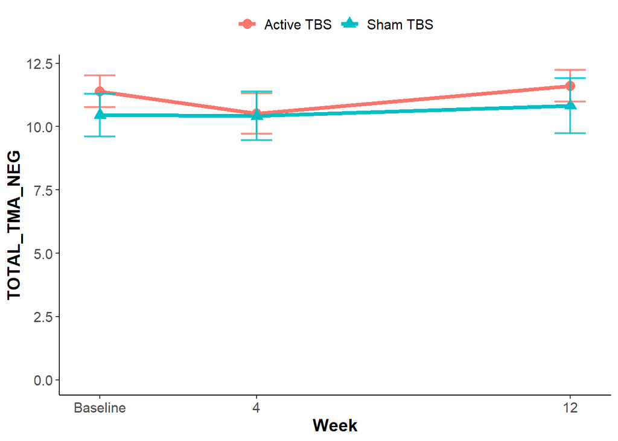

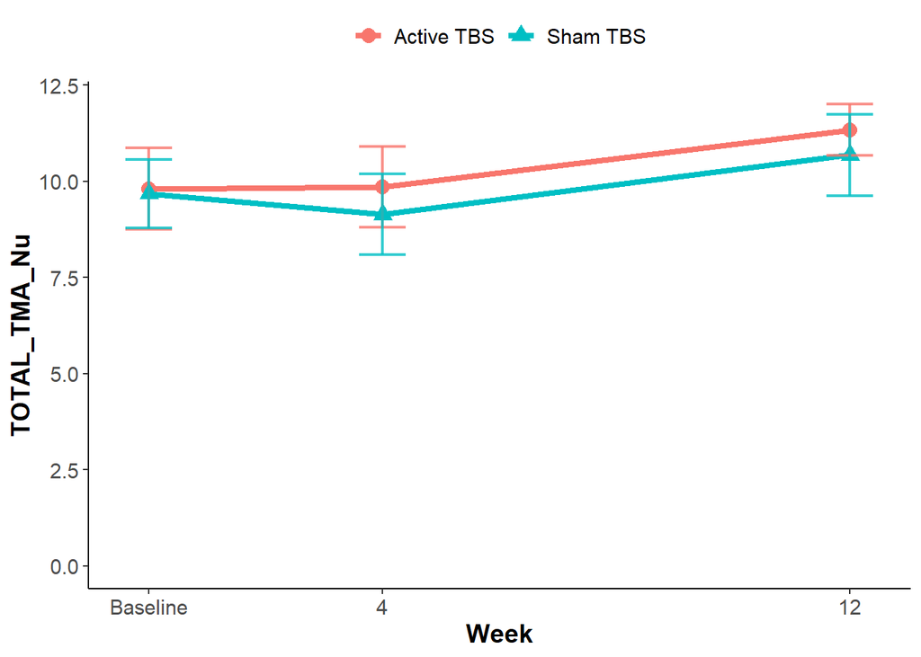

## 3.2 Response and Remission (HDRS)

| Condition | Type | Baseline | Week 1 | Week 2 | Week 4 | Week 6 | Week 8 | Week 12 |
| --- | --- | --- | --- | --- | --- | --- | --- | --- |
| Active TBS | HDRS remission - no. (%) | 0 (0) | 1 (2) | 3 (7) | 5 (12) | 8 (20) | 13 (32) | 14 (34) |
| Sham TBS | HDRS remission - no. (%) | 0 (0) | 3 (8) | 1 (3) | 1 (3) | 4 (11) | 7 (20) | 7 (19) |
| Active TBS | HDRS response - no. (%) | 0 (0) | 4 (10) | 8 (19) | 12 (29) | 16 (39) | 20 (49) | 20 (49) |
| Sham TBS | HDRS response - no. (%) | 0 (0) | 3 (8) | 4 (11) | 6 (17) | 10 (28) | 13 (37) | 11 (31) |

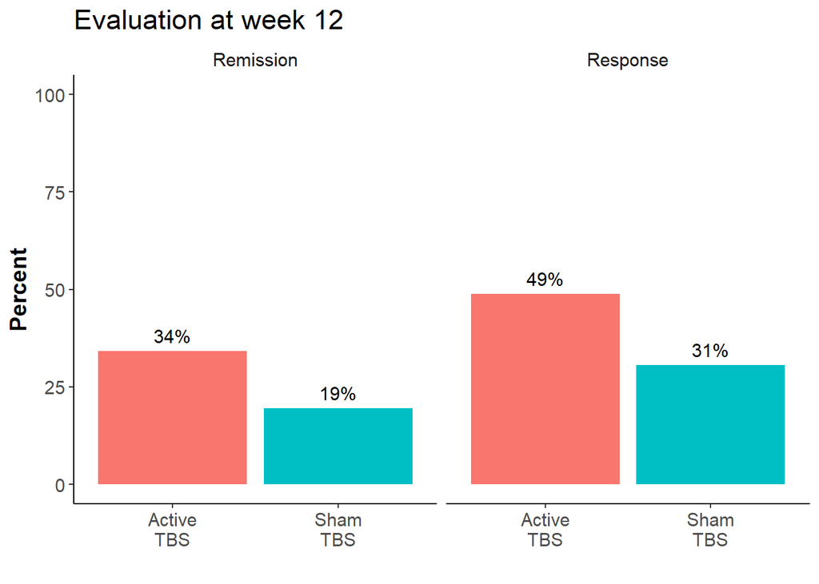

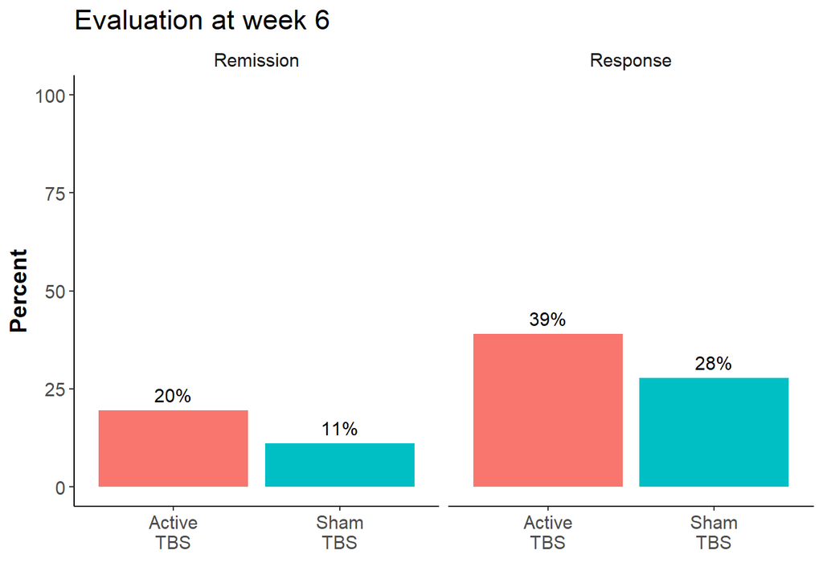

# 4 Statistical analysis

## 4.1 TBS effects on AMT

For each AMT measure, a separate linear mixed model was fit. All time points where AMT data was collected (baseline, weeks 4 and 12) were included. The AMT measure was the outcome, while time and condition were included as interacting fixed effects, and subject as a random effect (random intercept). A significant interaction would indicate that treatment had an effect on the AMT measure.

| Scale | Effect | Estimate | SE | t | DF | P | Cohen's d |
| --- | --- | --- | --- | --- | --- | --- | --- |
| TOTAL TMA | Main effect | 0.06 | 0.70 | 0.09 | 149.02 | 0.932 | 0.01 [-0.31, 0.34] |
|  | Interaction | -0.24 | 0.97 | -0.25 | 150.26 | 0.803 | -0.04 [-0.36, 0.28] |
| TOTAL TMA POS | Main effect | 0.09 | 0.20 | 0.44 | 147.46 | 0.660 | 0.07 [-0.25, 0.4] |
|  | Interaction | -0.26 | 0.28 | -0.92 | 148.44 | 0.358 | -0.15 [-0.47, 0.17] |
| TOTAL TMA NEG | Main effect | 0.14 | 0.20 | 0.70 | 146.52 | 0.486 | 0.12 [-0.21, 0.44] |
|  | Interaction | -0.14 | 0.28 | -0.50 | 147.38 | 0.621 | -0.08 [-0.4, 0.24] |
| TOTAL TMA NU | Main effect | 0.32 | 0.24 | 1.34 | 148.03 | 0.182 | 0.22 [-0.1, 0.54] |
|  | Interaction | 0.20 | 0.33 | 0.61 | 148.92 | 0.545 | 0.1 [-0.22, 0.42] |

*Notes:* Effects: Main Effect of time, interaction effect of time and group; Estimate: Coefficient (beta) of an effect/predictor; SE: standard error of the estimate; t: test statistic; DF: degrees of freedom, P: P-value; Cohen’s d: effect size with 95% confidence interval.

For example, total AMT scores did not change significantly over time/during the study (t = 0.09, DF = 149, P = 0.932) and total AMT score changes did not differ significantly between the active and the sham TBS groups (t = -0.25, DF = 150, P = 0.803).

## 4.2 Prediction of AMT change

Linear regression models were set up with AMT deltas (week 12 - baseline) as dependent variables and a predictor and group as interacting independent variables. Predictors were the NEO-PI-R sum scores and HDRS baseline measure. Each combination of AMT measure and predictor was tested in a separate linear regression. A significant main effect means the variable predicts AMT changes, independent of group. A significant interaction means the variable predicts TBS efficacy. However, as there were no significant changes in AMT measures across time and no TBS effects on AMT measures (previous section), it is unlikely to have findings for the current analyses.

| Predictor | Main effect Estimate | Main effect SE | Main effect t | Main effect P | Interaction Estimate | Interaction SE | Interaction t | Interaction P |
| --- | --- | --- | --- | --- | --- | --- | --- | --- |
| TOTAL_TMA |  |  |  |  |  |  |  |  |
| HDRS at baseline | -0.34 | 0.42 | -0.81 | 0.418 | 0.34 | 0.66 | 0.51 | 0.610 |
| Neuroticismo | 0.01 | 0.10 | 0.06 | 0.952 | -0.18 | 0.13 | -1.38 | 0.171 |
| Extroversao | 0.01 | 0.10 | 0.14 | 0.886 | 0.09 | 0.12 | 0.75 | 0.456 |
| Abertura | -0.01 | 0.08 | -0.10 | 0.924 | -0.03 | 0.11 | -0.29 | 0.770 |
| Amabilidade | -0.05 | 0.12 | -0.44 | 0.662 | 0.06 | 0.15 | 0.41 | 0.683 |
| Conscienciosidade | 0.10 | 0.09 | 1.13 | 0.264 | -0.06 | 0.12 | -0.47 | 0.641 |
| TOTAL_TMA_POS |  |  |  |  |  |  |  |  |
| HDRS at baseline | -0.12 | 0.13 | -0.90 | 0.372 | 0.05 | 0.21 | 0.25 | 0.803 |
| Neuroticismo | 0.01 | 0.03 | 0.27 | 0.786 | -0.01 | 0.04 | -0.20 | 0.838 |
| Extroversao | 0.01 | 0.03 | 0.42 | 0.676 | -0.01 | 0.04 | -0.32 | 0.748 |
| Abertura | 0.02 | 0.03 | 0.55 | 0.581 | -0.03 | 0.04 | -0.76 | 0.448 |
| Amabilidade | -0.04 | 0.04 | -1.12 | 0.266 | 0.05 | 0.05 | 0.92 | 0.363 |
| Conscienciosidade | 0.03 | 0.03 | 0.86 | 0.392 | -0.04 | 0.04 | -1.02 | 0.311 |
| TOTAL_TMA_NEG |  |  |  |  |  |  |  |  |
| HDRS at baseline | -0.14 | 0.14 | -1.01 | 0.316 | 0.21 | 0.23 | 0.91 | 0.366 |
| Neuroticismo | -0.01 | 0.04 | -0.41 | 0.686 | -0.04 | 0.05 | -0.92 | 0.361 |
| Extroversao | 0.02 | 0.04 | 0.67 | 0.507 | 0.02 | 0.04 | 0.38 | 0.707 |
| Abertura | -0.01 | 0.03 | -0.32 | 0.748 | 0.01 | 0.04 | 0.34 | 0.733 |
| Amabilidade | -0.05 | 0.04 | -1.06 | 0.291 | 0.05 | 0.06 | 0.89 | 0.379 |
| Conscienciosidade | 0.04 | 0.03 | 1.19 | 0.237 | -0.02 | 0.04 | -0.57 | 0.569 |
| TOTAL_TMA_Nu |  |  |  |  |  |  |  |  |
| HDRS at baseline | -0.08 | 0.19 | -0.40 | 0.687 | 0.08 | 0.30 | 0.27 | 0.791 |
| Neuroticismo | 0.01 | 0.04 | 0.25 | 0.804 | -0.13 | 0.06 | -2.16 | 0.035 |
| Extroversao | -0.02 | 0.05 | -0.52 | 0.608 | 0.09 | 0.06 | 1.56 | 0.123 |
| Abertura | -0.01 | 0.04 | -0.35 | 0.725 | -0.02 | 0.05 | -0.35 | 0.730 |
| Amabilidade | 0.04 | 0.06 | 0.67 | 0.504 | -0.03 | 0.07 | -0.45 | 0.652 |
| Conscienciosidade | 0.04 | 0.04 | 0.87 | 0.389 | 0.01 | 0.06 | 0.18 | 0.859 |

*Notes:* Main Effect of time, interaction effect of time and group. Estimate: Coefficient (beta) of an effect/predictor; SE: standard error of the estimate; t: test statistic; DF: degrees of freedom, P: P-value.

## 4.3 Correlations between AMT and NEO-PI-R measures

Mean AMT values over the three time points were calculated per subject and then correlated with NEO-PI-R measures.

The first table shows Pearson’s correlations, and the second shows the P-values for each correlation.High correlations between different AMT measures are expected.

| Pearson | TOTAL_TMA | TOTAL_TMA_POS | TOTAL_TMA_NEG | TOTAL_TMA_Nu | Neuroticismo | Extroversao | Abertura | Amabilidade |
| --- | --- | --- | --- | --- | --- | --- | --- | --- |
| TOTAL_TMA_POS | 0.87 |  |  |  |  |  |  |  |
| TOTAL_TMA_NEG | 0.90 | 0.76 |  |  |  |  |  |  |
| TOTAL_TMA_Nu | 0.90 | 0.67 | 0.70 |  |  |  |  |  |
| Neuroticismo | -0.04 | -0.05 | -0.09 | 0.06 |  |  |  |  |
| Extroversao | 0.07 | 0.03 | 0.10 | 0.00 | -0.41 |  |  |  |
| Abertura | 0.34 | 0.17 | 0.30 | 0.38 | -0.03 | 0.39 |  |  |
| Amabilidade | -0.04 | -0.05 | 0.00 | -0.05 | -0.02 | 0.07 | 0.27 |  |
| Conscienciosidade | -0.05 | -0.06 | 0.02 | -0.09 | -0.50 | 0.29 | -0.06 | 0.04 |

| P-values | TOTAL_TMA | TOTAL_TMA_POS | TOTAL_TMA_NEG | TOTAL_TMA_Nu | Neuroticismo | Extroversao | Abertura | Amabilidade |
| --- | --- | --- | --- | --- | --- | --- | --- | --- |
| TOTAL_TMA_POS | 0.000 |  |  |  |  |  |  |  |
| TOTAL_TMA_NEG | 0.000 | 0.000 |  |  |  |  |  |  |
| TOTAL_TMA_Nu | 0.000 | 0.000 | 0.000 |  |  |  |  |  |
| Neuroticismo | 0.748 | 0.699 | 0.447 | 0.650 |  |  |  |  |
| Extroversao | 0.595 | 0.800 | 0.391 | 0.987 | 0.000 |  |  |  |
| Abertura | 0.004 | 0.153 | 0.012 | 0.001 | 0.789 | 0.001 |  |  |
| Amabilidade | 0.752 | 0.698 | 0.984 | 0.660 | 0.887 | 0.578 | 0.022 |  |
| Conscienciosidade | 0.691 | 0.641 | 0.884 | 0.473 | 0.000 | 0.015 | 0.633 | 0.722 |

## 4.4 TBS effects on HDRS

Before running predictive analyses, it makes sense to investigate if the treatment of interest was effective. It is easier to find predictors of TBS efficacy if TBS reduced depressive symptoms.

In the original sample of 108 subjects, TBS significantly improved depressive symptoms if all data until week 12 was included (P = 0.045), but was barely not significant when only data until week 6, the primary study endpoint, was analysed (P = 0.059).

In the subsequent predictive analyses, AMT and NEO-PI data are investigated as predictors of TBS response. Because of missing AMT and NEO-PI data, two different subsamples will be used for these analyses. It is interesting to see how the TBS effect on HDRS behaves in these subsamples.

A linear mixed-effects model was used to investigate if treatment was effective was in the two different subsamples used for the subsequent predictive analyses for AMT and NEO PI measures. Time was assumed to be linear on a natural logarithmic scale. HDRS-17 was the outcome, group and time were included as interacting fixed effects, and subject as random-intercept effect.

### 4.4.1 NEO PI subsample

```
## [1] "Week 12 as endpoint:"
```

```
##                              Estimate Std Error     df t value     P
## (Intercept)                     19.94      0.80 149.35   25.05 0.000
## conditionActive TBS             -0.10      1.10 149.31   -0.09 0.926
## time_log                        -2.81      0.31 452.12   -9.19 0.000
## conditionActive TBS:time_log    -0.85      0.42 452.08   -2.01 0.045
```

In the NEO PI subsample with week 12 as endpoint, results showed a reduction in HDRS-17 scores across time, independent of group (t(452) = -9.19, P < .001). There was a significant interaction of group and time (t(452) = -2.01, P = 0.045). This indicates that active TBS treatment was effective in reducing depressive symptoms.

(The other analyses in this section can be interpreted analogously.)

```
## [1] "Week 6 as endpoint:"
```

```
##                              Estimate Std Error     df t value     P
## (Intercept)                     20.47      0.74 155.25   27.68 0.000
## conditionActive TBS              0.07      1.02 155.25    0.07 0.944
## time_log                        -3.51      0.40 301.16   -8.83 0.000
## conditionActive TBS:time_log    -1.09      0.55 301.11   -1.98 0.048
```

### 4.4.2 AMT subsample

```
## [1] "Week 12 as endpoint:"
```

```
##                              Estimate Std Error     df t value     P
## (Intercept)                     19.98      0.76 162.47   26.45 0.000
## conditionActive TBS             -0.42      1.04 162.39   -0.40 0.687
## time_log                        -2.84      0.30 460.23   -9.36 0.000
## conditionActive TBS:time_log    -0.84      0.42 459.56   -2.01 0.044
```

```
## [1] "Week 6 as endpoint:"
```

```
##                              Estimate Std Error     df t value     P
## (Intercept)                     20.53      0.71 169.53   29.01 0.000
## conditionActive TBS             -0.32      0.98 169.50   -0.33 0.745
## time_log                        -3.57      0.40 307.70   -8.97 0.000
## conditionActive TBS:time_log    -0.99      0.55 307.16   -1.80 0.072
```

## 4.5 Prediction of HDRS (antidepressant response)

Predictors are AMT measures at baseline and all NEO PI measures, which were evaluated for HDRS changes (deltas) from baseline to endpoint using linear regression and for HDRS response using logistic regression (generalized linear model). For each predictor, separate models were set up with the outcome referring to Week 6 or 12 as endpoint. Group and predictor were included as interacting factors. A significant main effect of the predictor indicates that the predictor had an effect on HDRS changes/responses on the whole sample, independent of group. A significant interaction of the predictor and group is the “desirable” outcome: It indicates that this measure predicts TBS effectiveness.

Because of the big number of tests, it’s likely that some significant findings are “false positives”, which means they are significant based on chance alone. There are several ways to counteract this:

- Reduce the number of tests based on theory
- Use a correction for multiple comparisons. With the current number of tests, it seems unlikely they would stay significant after correction.

### 4.5.1 Predictors of HDRS change

| Predictor | Main effect Estimate | Main effect SE | Main effect t | Main effect P | Interaction Estimate | Interaction SE | Interaction t | Interaction P |
| --- | --- | --- | --- | --- | --- | --- | --- | --- |
| Week 6 |  |  |  |  |  |  |  |  |
| AMT total | 0.06 | 0.16 | 0.38 | 0.707 | -0.11 | 0.21 | -0.50 | 0.618 |
| AMT positive | 0.00 | 0.44 | -0.01 | 0.995 | -0.14 | 0.68 | -0.20 | 0.841 |
| AMT negative | 0.17 | 0.38 | 0.46 | 0.647 | -0.27 | 0.61 | -0.44 | 0.661 |
| AMT neutral | 0.16 | 0.36 | 0.45 | 0.657 | -0.26 | 0.46 | -0.58 | 0.567 |
| Neuroticismo | 0.00 | 0.08 | -0.03 | 0.979 | 0.09 | 0.10 | 0.91 | 0.364 |
| Extroversao | -0.06 | 0.08 | -0.78 | 0.439 | -0.05 | 0.10 | -0.56 | 0.580 |
| Abertura | -0.02 | 0.07 | -0.37 | 0.715 | -0.01 | 0.09 | -0.12 | 0.903 |
| Amabilidade | 0.09 | 0.10 | 0.93 | 0.356 | -0.06 | 0.12 | -0.53 | 0.599 |
| Conscienciosidade | 0.10 | 0.08 | 1.33 | 0.189 | -0.06 | 0.10 | -0.60 | 0.553 |
| Neuroticismo ansiedade | 0.48 | 0.35 | 1.37 | 0.175 | 0.12 | 0.44 | 0.28 | 0.781 |
| Neuroticismo raiva | 0.26 | 0.29 | 0.89 | 0.377 | -0.10 | 0.39 | -0.25 | 0.802 |
| Neuroticismo depressao | 0.03 | 0.32 | 0.09 | 0.930 | 0.11 | 0.39 | 0.28 | 0.782 |
| Neuroticismo embaraco | -0.31 | 0.31 | -1.02 | 0.312 | 0.82 | 0.40 | 2.04 | 0.045 |
| Neuroticismo impulsividade | -0.70 | 0.33 | -2.15 | 0.035 | 0.68 | 0.39 | 1.76 | 0.082 |
| Neuroticismo vulnerabilidade | 0.16 | 0.27 | 0.60 | 0.548 | -0.12 | 0.37 | -0.33 | 0.745 |
| Extroversao acolhimento | -0.15 | 0.25 | -0.59 | 0.557 | -0.36 | 0.32 | -1.14 | 0.260 |
| Extroversao gregarismo | 0.13 | 0.27 | 0.46 | 0.644 | -0.42 | 0.34 | -1.24 | 0.219 |
| Extroversao assertividade | 0.13 | 0.30 | 0.44 | 0.659 | -0.16 | 0.39 | -0.40 | 0.693 |
| Extroversao atividade | -0.22 | 0.34 | -0.64 | 0.522 | 0.00 | 0.43 | 0.01 | 0.994 |
| Extroversao busca de sensacoes | -0.77 | 0.35 | -2.18 | 0.032 | 0.37 | 0.45 | 0.83 | 0.408 |
| Extroversao emocoes positivas | -0.16 | 0.25 | -0.65 | 0.516 | -0.07 | 0.32 | -0.23 | 0.822 |
| Extroversao emocoes positivas extroversao | -0.07 | 0.11 | -0.64 | 0.525 | -0.04 | 0.14 | -0.28 | 0.782 |
| Abertura fantasia | -0.12 | 0.26 | -0.46 | 0.644 | -0.14 | 0.34 | -0.43 | 0.670 |
| Abertura estetica | 0.07 | 0.30 | 0.23 | 0.822 | -0.23 | 0.38 | -0.61 | 0.545 |
| Abertura sentimento | 0.17 | 0.33 | 0.53 | 0.598 | -0.23 | 0.44 | -0.53 | 0.596 |
| Abertura acoes variadas | 0.05 | 0.30 | 0.15 | 0.880 | 0.00 | 0.39 | 0.01 | 0.996 |
| Abertura ideias | -0.16 | 0.20 | -0.77 | 0.441 | 0.08 | 0.29 | 0.26 | 0.796 |
| Abertura valores | -0.22 | 0.28 | -0.77 | 0.444 | 0.16 | 0.39 | 0.41 | 0.685 |
| Amabilidade confianca | 0.55 | 0.33 | 1.66 | 0.101 | -0.52 | 0.38 | -1.35 | 0.182 |

[output cut: 52 more lines]

*Notes:* Main Effect of time, interaction effect of time and group. Estimate: Coefficient (beta) of an effect/predictor; SE: standard error of the estimate; t: test statistic; DF: degrees of freedom, P: P-value.

### 4.5.2 Predictors HDRS response

Response is defined as at least a 50% reduction in the HDRS score from baseline to endpoint. weeks 6 and 12 are analyzed as endpoints.

| Predictor | Main effect Odds ratio | Main effect z | Main effect P | Interaction Odds ratio | Interaction z | Interaction P |
| --- | --- | --- | --- | --- | --- | --- |
| Week 6 |  |  |  |  |  |  |
| AMT total | 1.01 | 0.11 | 0.912 | 0.98 | -0.21 | 0.834 |
| AMT positive | 1.05 | 0.31 | 0.757 | 0.96 | -0.19 | 0.853 |
| AMT negative | 1.00 | -0.02 | 0.981 | 0.93 | -0.33 | 0.739 |
| AMT neutral | 1.00 | 0.02 | 0.982 | 0.99 | -0.08 | 0.933 |
| Neuroticismo | 1.01 | 0.33 | 0.745 | 0.95 | -1.18 | 0.236 |
| Extroversao | 1.04 | 1.25 | 0.212 | 1.01 | 0.35 | 0.728 |
| Abertura | 1.03 | 1.05 | 0.294 | 1.00 | -0.03 | 0.980 |
| Amabilidade | 0.96 | -1.09 | 0.274 | 1.05 | 1.05 | 0.292 |
| Conscienciosidade | 0.97 | -1.07 | 0.284 | 1.05 | 1.24 | 0.214 |
| Neuroticismo ansiedade | 0.91 | -0.69 | 0.492 | 0.88 | -0.68 | 0.494 |
| Neuroticismo raiva | 0.89 | -0.95 | 0.340 | 0.95 | -0.32 | 0.750 |
| Neuroticismo depressao | 1.02 | 0.14 | 0.891 | 0.86 | -1.00 | 0.316 |
| Neuroticismo embaraco | 1.19 | 1.36 | 0.174 | 0.71 | -2.12 | 0.034 |
| Neuroticismo impulsividade | 1.45 | 2.19 | 0.028 | 0.71 | -1.87 | 0.061 |
| Neuroticismo vulnerabilidade | 0.93 | -0.74 | 0.459 | 1.15 | 1.05 | 0.294 |
| Extroversao acolhimento | 1.11 | 0.97 | 0.333 | 1.10 | 0.66 | 0.509 |
| Extroversao gregarismo | 0.95 | -0.48 | 0.628 | 1.18 | 1.29 | 0.197 |
| Extroversao assertividade | 1.06 | 0.51 | 0.607 | 0.96 | -0.29 | 0.772 |
| Extroversao atividade | 1.05 | 0.37 | 0.713 | 1.10 | 0.57 | 0.571 |
| Extroversao busca de sensacoes | 1.43 | 1.97 | 0.049 | 0.79 | -1.09 | 0.275 |
| Extroversao emocoes positivas | 1.13 | 1.23 | 0.217 | 1.03 | 0.23 | 0.820 |
| Extroversao emocoes positivas extroversao | 1.05 | 1.01 | 0.312 | 1.03 | 0.53 | 0.598 |
| Abertura fantasia | 1.12 | 1.14 | 0.254 | 1.06 | 0.43 | 0.667 |
| Abertura estetica | 1.09 | 0.76 | 0.445 | 0.94 | -0.47 | 0.640 |
| Abertura sentimento | 0.93 | -0.57 | 0.566 | 1.16 | 0.93 | 0.353 |
| Abertura acoes variadas | 1.03 | 0.29 | 0.768 | 1.06 | 0.38 | 0.704 |
| Abertura ideias | 1.10 | 1.14 | 0.255 | 0.97 | -0.25 | 0.801 |
| Abertura valores | 1.12 | 1.04 | 0.298 | 0.92 | -0.60 | 0.549 |
| Amabilidade confianca | 0.76 | -1.86 | 0.062 | 1.40 | 2.08 | 0.037 |

[output cut: 52 more lines]

*Notes:* Main Effect of time, interaction effect of time and group. Odds ratio: The change in odds of response for a one-unit change in the predictor variable; Z: test statistic; P: P-value. If the interaction is significant, the main effect cannot be interpreted.

### 4.5.3 Predictors HDRS remission

| Predictor | Main effect Odds ratio | Main effect z | Main effect P | Interaction Odds ratio | Interaction z | Interaction P |
| --- | --- | --- | --- | --- | --- | --- |
| Week 6 |  |  |  |  |  |  |
| AMT total | 1.19 | 1.72 | 0.085 | 0.85 | -1.34 | 0.179 |
| AMT positive | 1.57 | 1.46 | 0.144 | 0.60 | -1.37 | 0.170 |
| AMT negative | 1.43 | 1.41 | 0.158 | 0.75 | -0.88 | 0.377 |
| AMT neutral | 1.48 | 1.60 | 0.110 | 0.71 | -1.25 | 0.210 |
| Neuroticismo | 0.99 | -0.25 | 0.800 | 1.00 | -0.09 | 0.925 |
| Extroversao | 1.08 | 1.61 | 0.107 | 0.92 | -1.49 | 0.136 |
| Abertura | 1.08 | 2.00 | 0.046 | 0.91 | -2.01 | 0.045 |
| Amabilidade | 0.98 | -0.35 | 0.723 | 0.99 | -0.21 | 0.837 |
| Conscienciosidade | 0.97 | -0.66 | 0.506 | 1.02 | 0.49 | 0.627 |
| Neuroticismo ansiedade | 0.87 | -0.78 | 0.435 | 0.93 | -0.29 | 0.769 |
| Neuroticismo raiva | 1.01 | 0.09 | 0.929 | 0.91 | -0.50 | 0.615 |
| Neuroticismo depressao | 0.93 | -0.45 | 0.656 | 0.99 | -0.07 | 0.947 |
| Neuroticismo embaraco | 1.09 | 0.49 | 0.625 | 0.82 | -0.97 | 0.332 |
| Neuroticismo impulsividade | 1.46 | 1.52 | 0.128 | 0.72 | -1.23 | 0.219 |
| Neuroticismo vulnerabilidade | 0.75 | -1.62 | 0.104 | 1.54 | 2.09 | 0.037 |
| Extroversao acolhimento | 1.44 | 1.59 | 0.113 | 0.72 | -1.33 | 0.184 |
| Extroversao gregarismo | 0.88 | -0.83 | 0.409 | 1.21 | 1.06 | 0.287 |
| Extroversao assertividade | 1.18 | 1.01 | 0.315 | 0.72 | -1.63 | 0.102 |
| Extroversao atividade | 1.13 | 0.64 | 0.522 | 0.86 | -0.66 | 0.511 |
| Extroversao busca de sensacoes | 1.34 | 1.24 | 0.214 | 0.79 | -0.90 | 0.368 |
| Extroversao emocoes positivas | 1.36 | 1.91 | 0.056 | 0.70 | -1.97 | 0.049 |
| Extroversao emocoes positivas extroversao | 1.13 | 1.72 | 0.085 | 0.87 | -1.74 | 0.081 |
| Abertura fantasia | 1.25 | 1.52 | 0.129 | 0.94 | -0.31 | 0.756 |
| Abertura estetica | 1.07 | 0.41 | 0.685 | 0.89 | -0.61 | 0.544 |
| Abertura sentimento | 1.17 | 0.92 | 0.358 | 0.77 | -1.19 | 0.232 |
| Abertura acoes variadas | 1.37 | 1.57 | 0.117 | 0.59 | -2.22 | 0.027 |
| Abertura ideias | 1.30 | 1.90 | 0.058 | 0.69 | -2.21 | 0.027 |
| Abertura valores | 1.51 | 1.94 | 0.052 | 0.65 | -1.79 | 0.074 |
| Amabilidade confianca | 0.64 | -2.01 | 0.044 | 1.51 | 1.74 | 0.083 |

[output cut: 52 more lines]

*Notes:* Main Effect of time, interaction effect of time and group. Odds ratio: The change in odds of response for a one-unit change in the predictor variable; Z: test statistic; P: P-value. If the interaction is significant, the main effect cannot be interpreted.